# Set_20 Subset selection for linear regression

Alexander Williams

2024-11-26

# Subset Selection for Linear Regression

This is the start of the “special topics” section of the coursem and it uses the other textbook “An Introduction to Statistical Learning with Applications in R”

Lets go back to multiple regression:
$$Y=\beta_0+\beta_1X_1+...+\beta_pX_p+\epsilon$$

What we’ve done so far when selecting variables is we start with all variables, then remove the least significant ones. This was backwards selection

lets look at Best subset selection: let $M_0$ denote the null model, with only an intercept. for $k=1,...,p$, fit all $_kC_p$ that have exactly $k$ variables. choose the best model with the smallest Residual sum of squares (RSS) and call that $M_k$.

We can’t use RSS to test which model is best out of $M_0,...,M_p$ since RSS will always be smaller for the models with more terms. There,s a few methods we can use to select the best method:

- $$C_p:\frac{1}{n}(RSS+2d\hat\sigma^2)$$
  Where $d$ is the number of variables in the model, $2d\hat\sigma^2$ is the penalty for adding parameters to a model.
- $AIC:\frac{1}{n\hat\sigma^2}(RSS+2d\hat\sigma)$
- $BIC:\frac{1}{n\hat\sigma^2}(RSS+log(n)d\hat\sigma)$ slightly different penalty compared to AIC, now the penalty increases with the sample size, instead of at a constant rate of 2.
- Adjusted $R^2$: $R^2$ with a penalty for larger numbers of variables.
  $$1-\frac{RSS/(n-d-1)}{TSS/(n-1)}$$

You can also use cross-validation, like in SENG 474. Train the model on a subset of the data, test on the other subset. We use the results of the test set to compute the MSE. We can extend this to k-fold validation, by splitting the data into k “folds”, training a model on each set of $k-1$ folds, and test on the remaining fold. we then take the average of each models MSE.

How do we choose how many folds? More folds means we get a smaller test set, but less folds means a smaller training set. 10-fold is pretty common

Cross validation is got for predictive models, while BIC might be best to find the true model, or to make inferences.

with best subset selection, we need to test $2^p$ models, which is completely unfeasible in larger models, it can only be done up to about $p=40$. This is why step-wise methods such as forwards or backwards selection is used.

Forward selection:

Stat with $M_0$

Add the predictor that improves the fit the most, looking at RSS. Repeat until you have $M_0,...,M_p$

choose the best model from those p models, same as best fit.

# Example

this is on the built-in dataset “Hitters”

```r
library(ISLR)
#fix(Hitters)
names(Hitters)
```

```
##  [1] "AtBat"     "Hits"      "HmRun"     "Runs"      "RBI"       "Walks"
##  [7] "Years"     "CAtBat"    "CHits"     "CHmRun"    "CRuns"     "CRBI"
## [13] "CWalks"    "League"    "Division"  "PutOuts"   "Assists"   "Errors"
## [19] "Salary"    "NewLeague"
```

```r
dim(Hitters)
```

```
## [1] 322  20
```

```r
sum(is.na(Hitters$Salary))
```

```
## [1] 59
```

```r
Hitters <- na.omit(Hitters) # remove any missing values. Not a good way of handling large amounts of missing data.
# It can be better to impute the data, things like fill the NA values with mean\medians
dim(Hitters)
```

```
## [1] 263  20
```

```r
library(leaps)
# Best Subset Regression, trying to predict salary using '.', which means everything else
regfit.full <- regsubsets(Salary~.,Hitters)
summary(regfit.full)
```

```
## Subset selection object
## Call: regsubsets.formula(Salary ~ ., Hitters)
## 19 Variables  (and intercept)
##            Forced in Forced out
## AtBat          FALSE      FALSE
## Hits           FALSE      FALSE
## HmRun          FALSE      FALSE
## Runs           FALSE      FALSE
## RBI            FALSE      FALSE
## Walks          FALSE      FALSE
## Years          FALSE      FALSE
## CAtBat         FALSE      FALSE
## CHits          FALSE      FALSE
## CHmRun         FALSE      FALSE
## CRuns          FALSE      FALSE
## CRBI           FALSE      FALSE
## CWalks         FALSE      FALSE
## LeagueN        FALSE      FALSE
## DivisionW      FALSE      FALSE
## PutOuts        FALSE      FALSE
## Assists        FALSE      FALSE
## Errors         FALSE      FALSE
## NewLeagueN     FALSE      FALSE
## 1 subsets of each size up to 8
## Selection Algorithm: exhaustive
##          AtBat Hits HmRun Runs RBI Walks Years CAtBat CHits CHmRun CRuns CRBI
## 1  ( 1 ) " "   " "  " "   " "  " " " "   " "   " "    " "   " "    " "   "*"
## 2  ( 1 ) " "   "*"  " "   " "  " " " "   " "   " "    " "   " "    " "   "*"
## 3  ( 1 ) " "   "*"  " "   " "  " " " "   " "   " "    " "   " "    " "   "*"
## 4  ( 1 ) " "   "*"  " "   " "  " " " "   " "   " "    " "   " "    " "   "*"
## 5  ( 1 ) "*"   "*"  " "   " "  " " " "   " "   " "    " "   " "    " "   "*"
## 6  ( 1 ) "*"   "*"  " "   " "  " " "*"   " "   " "    " "   " "    " "   "*"
## 7  ( 1 ) " "   "*"  " "   " "  " " "*"   " "   "*"    "*"   "*"    " "   " "
## 8  ( 1 ) "*"   "*"  " "   " "  " " "*"   " "   " "    " "   "*"    "*"   " "
##          CWalks LeagueN DivisionW PutOuts Assists Errors NewLeagueN
## 1  ( 1 ) " "    " "     " "       " "     " "     " "    " "
## 2  ( 1 ) " "    " "     " "       " "     " "     " "    " "
## 3  ( 1 ) " "    " "     " "       "*"     " "     " "    " "
## 4  ( 1 ) " "    " "     "*"       "*"     " "     " "    " "
## 5  ( 1 ) " "    " "     "*"       "*"     " "     " "    " "
## 6  ( 1 ) " "    " "     "*"       "*"     " "     " "    " "
## 7  ( 1 ) " "    " "     "*"       "*"     " "     " "    " "
## 8  ( 1 ) "*"    " "     "*"       "*"     " "     " "    " "
```

Row 1 in the grid means model with only 1 predictor. The star shows what’s in it, so CRBI is the best if there’s only one predictor. If there’s two, it’s CRBI and Hits. Note that the grid is so wide it’s split in 2, the bottom grid is part of the top one.

```r
regfit.full = regsubsets(Salary~.,Hitters,nvmax = 19)
reg.summary = summary(regfit.full)
names(reg.summary)
```

```
## [1] "which"  "rsq"    "rss"    "adjr2"  "cp"     "bic"    "outmat" "obj"
```

```r
reg.summary$rsq
```

```
##  [1] 0.3214501 0.4252237 0.4514294 0.4754067 0.4908036 0.5087146 0.5141227
##  [8] 0.5285569 0.5346124 0.5404950 0.5426153 0.5436302 0.5444570 0.5452164
## [15] 0.5454692 0.5457656 0.5459518 0.5460945 0.5461159
```

You can see that the rsq or $R^2$ goes up as we increase the size of the model, much faster when there’s not many variables. We can plot these summaries.

lets plot RSS against num. variables, and adjusted $R^2$ against num. variables

```r
par(mfrow=c(2,2))
plot(reg.summary$rss,xlab='Number of Variables',ylab = 'RSS', type = 'l')
plot(reg.summary$adjr2 ,xlab="Number of Variables ", ylab="Adjusted RSq",type='l')
which.max(reg.summary$adjr2)
```

```
## [1] 11
```

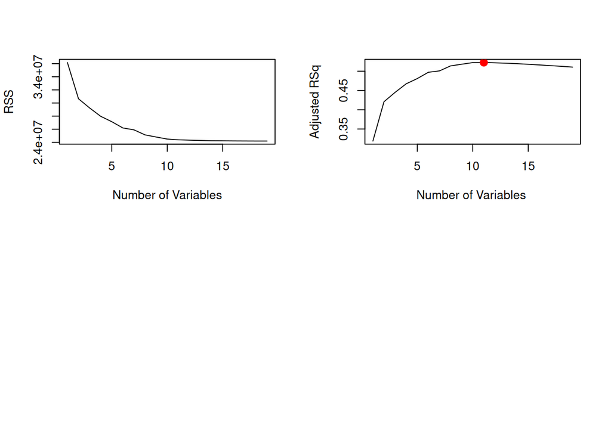

```r
# model with 11 predictors did best for adjusted rsq, lets highlight that in the graph
points(11,reg.summary$adjr2[11], col="red",cex=2,pch=20)
```

Lets also compare the number of variables to $C_p$ and highlight the best/lowest score

```r
plot(reg.summary$cp ,xlab="Number of Variables ",ylab="Cp", type='l')
which.min(reg.summary$cp )
```

```
## [1] 10
```

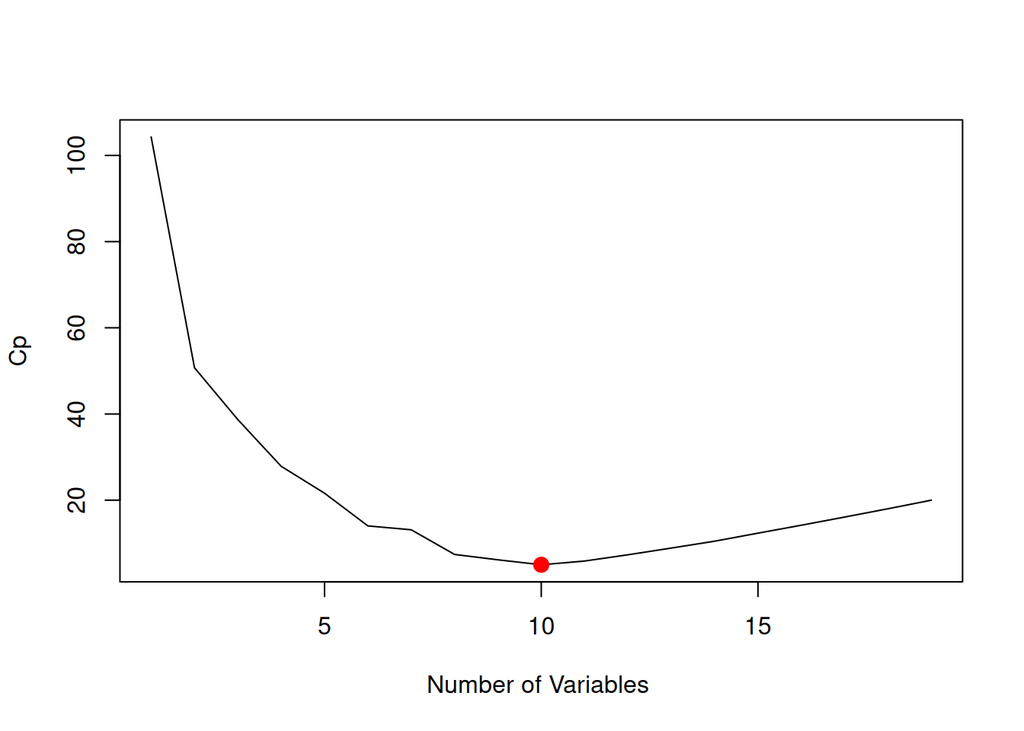

```r
# 10 variables is best
points(10,reg.summary$cp [10],col="red",cex=2,pch=20)
```

Last of all, we can do BIC, which penalizes large models a lot more

```r
plot(reg.summary$bic ,xlab="Number of Variables ",ylab="BIC", type='l')
which.min(reg.summary$bic )
```

```
## [1] 6
```

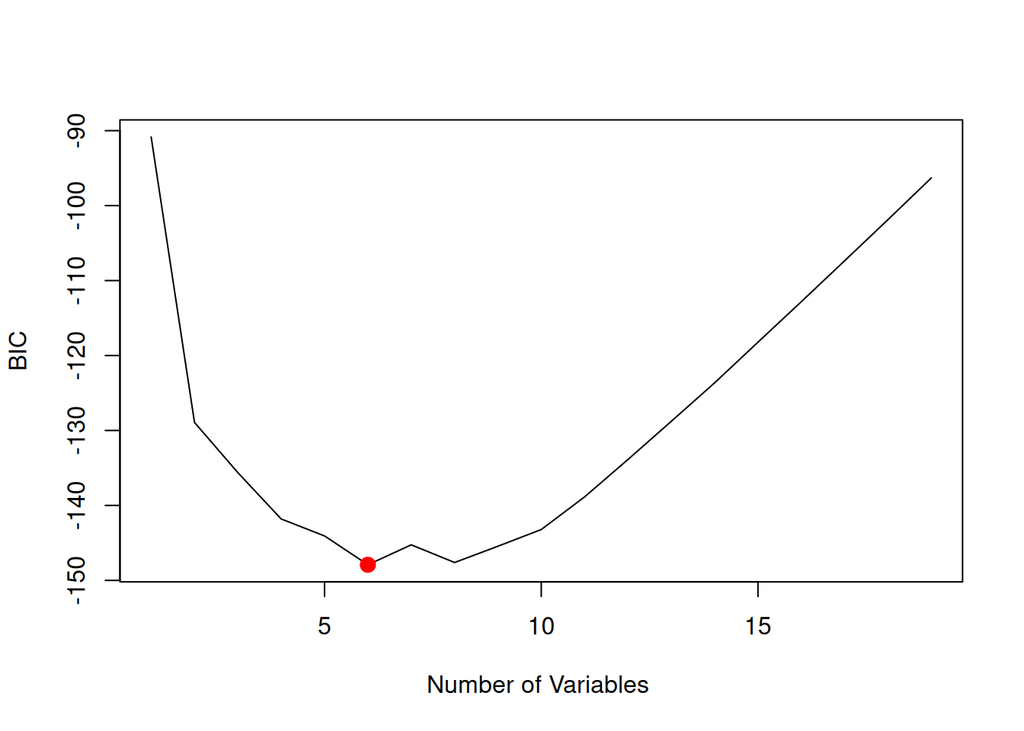

```r
# 6 is best according to BIC
points(6,reg.summary$bic [6],col="red",cex=2,pch=20)
```

we can extract the coefficients easily

```r
coef(regfit.full ,6)
```

```
##  (Intercept)        AtBat         Hits        Walks         CRBI    DivisionW
##   91.5117981   -1.8685892    7.6043976    3.6976468    0.6430169 -122.9515338
##      PutOuts
##    0.2643076
```

What do we get with forward selection instead of best selection? Best selection is always better, but in a large dataset might not be feasible to do.

```r
regfit.fwd <- regsubsets(Salary~.,data=Hitters ,nvmax=19, method ='forward')
summary(regfit.fwd)
```

```
## Subset selection object
## Call: regsubsets.formula(Salary ~ ., data = Hitters, nvmax = 19, method = "forward")
## 19 Variables  (and intercept)
##            Forced in Forced out
## AtBat          FALSE      FALSE
## Hits           FALSE      FALSE
## HmRun          FALSE      FALSE
## Runs           FALSE      FALSE
## RBI            FALSE      FALSE
## Walks          FALSE      FALSE
## Years          FALSE      FALSE
## CAtBat         FALSE      FALSE
## CHits          FALSE      FALSE
## CHmRun         FALSE      FALSE
## CRuns          FALSE      FALSE
## CRBI           FALSE      FALSE
## CWalks         FALSE      FALSE
## LeagueN        FALSE      FALSE
## DivisionW      FALSE      FALSE
## PutOuts        FALSE      FALSE
## Assists        FALSE      FALSE
## Errors         FALSE      FALSE
## NewLeagueN     FALSE      FALSE
## 1 subsets of each size up to 19
## Selection Algorithm: forward
##           AtBat Hits HmRun Runs RBI Walks Years CAtBat CHits CHmRun CRuns CRBI
## 1  ( 1 )  " "   " "  " "   " "  " " " "   " "   " "    " "   " "    " "   "*"
## 2  ( 1 )  " "   "*"  " "   " "  " " " "   " "   " "    " "   " "    " "   "*"
## 3  ( 1 )  " "   "*"  " "   " "  " " " "   " "   " "    " "   " "    " "   "*"
## 4  ( 1 )  " "   "*"  " "   " "  " " " "   " "   " "    " "   " "    " "   "*"
## 5  ( 1 )  "*"   "*"  " "   " "  " " " "   " "   " "    " "   " "    " "   "*"
## 6  ( 1 )  "*"   "*"  " "   " "  " " "*"   " "   " "    " "   " "    " "   "*"
## 7  ( 1 )  "*"   "*"  " "   " "  " " "*"   " "   " "    " "   " "    " "   "*"
## 8  ( 1 )  "*"   "*"  " "   " "  " " "*"   " "   " "    " "   " "    "*"   "*"
## 9  ( 1 )  "*"   "*"  " "   " "  " " "*"   " "   "*"    " "   " "    "*"   "*"
## 10  ( 1 ) "*"   "*"  " "   " "  " " "*"   " "   "*"    " "   " "    "*"   "*"
## 11  ( 1 ) "*"   "*"  " "   " "  " " "*"   " "   "*"    " "   " "    "*"   "*"
## 12  ( 1 ) "*"   "*"  " "   "*"  " " "*"   " "   "*"    " "   " "    "*"   "*"
## 13  ( 1 ) "*"   "*"  " "   "*"  " " "*"   " "   "*"    " "   " "    "*"   "*"
## 14  ( 1 ) "*"   "*"  "*"   "*"  " " "*"   " "   "*"    " "   " "    "*"   "*"
```

[output cut: 10 more lines]

```
## 5  ( 1 )  " "    " "     "*"       "*"     " "     " "    " "
## 6  ( 1 )  " "    " "     "*"       "*"     " "     " "    " "
## 7  ( 1 )  "*"    " "     "*"       "*"     " "     " "    " "
## 8  ( 1 )  "*"    " "     "*"       "*"     " "     " "    " "
## 9  ( 1 )  "*"    " "     "*"       "*"     " "     " "    " "
## 10  ( 1 ) "*"    " "     "*"       "*"     "*"     " "    " "
## 11  ( 1 ) "*"    "*"     "*"       "*"     "*"     " "    " "
## 12  ( 1 ) "*"    "*"     "*"       "*"     "*"     " "    " "
## 13  ( 1 ) "*"    "*"     "*"       "*"     "*"     "*"    " "
## 14  ( 1 ) "*"    "*"     "*"       "*"     "*"     "*"    " "
## 15  ( 1 ) "*"    "*"     "*"       "*"     "*"     "*"    " "
## 16  ( 1 ) "*"    "*"     "*"       "*"     "*"     "*"    " "
## 17  ( 1 ) "*"    "*"     "*"       "*"     "*"     "*"    "*"
## 18  ( 1 ) "*"    "*"     "*"       "*"     "*"     "*"    "*"
## 19  ( 1 ) "*"    "*"     "*"       "*"     "*"     "*"    "*"
```

Another way to select variables is with cross validation

```r
set.seed <- 1 # for consistency
train=sample(c(TRUE,FALSE),nrow(Hitters),rep=TRUE)
test <- (!train)


# validation
regfit.best=regsubsets(Salary~.,data=Hitters[train,], nvmax =19)
test.mat=model.matrix(Salary~.,data=Hitters[test,])
val.errors=rep(NA,19)
for(i in 1:19)
  {
  coefi=coef(regfit.best,id=i)
  pred=test.mat[,names(coefi)]%*%coefi
  val.errors[i]=mean((Hitters$Salary[test]-pred)^2)
}

# Checking results
val.errors
```

```
##  [1] 118010.9 133908.7 103840.6 127005.3 113715.7 110294.6 104440.2 114176.1
##  [9] 117376.3 116617.3 117784.2 118092.3 120401.0 121626.5 121082.3 121534.0
## [17] 121676.1 120937.0 121071.2
```

```r
which.min(val.errors)
```

```
## [1] 3
```

```r
coef(regfit.best ,which.min(val.errors))
```

```
## (Intercept)       Walks      CAtBat       CHits
## 111.6256944   6.2605729  -0.5562029   2.2978430
```

again, cross-validation is best for when you’re making predictions, but when you’re trying to make inferences, it’s often best to use BIC

We can put all of that code into one function, to do it all for us

```r
predict.regsubsets =function (object ,newdata ,id ,...)
{
  form <- as.formula(object$call [[2]])
  mat <- model.matrix(form,newdata)
  coefi <- coef(object ,id=id)
  xvars <- names(coefi)
  mat[,xvars]%*%coefi
}
```

Now, we can use this to do cross validation in a better way. We can do k-fold cross-validation.

```r
k <- 10
set.seed(1)
folds <- sample(1:k, nrow(Hitters), replace=TRUE) # make folds

cv.errors <- matrix(NA,k,19, dimnames=list(NULL, paste(1:19)))

# cross-validation loop, loops through all folds
for(j in 1:k)
{
  best.fit <- regsubsets (Salary ~. , data = Hitters[folds != j , ] ,  nvmax =19)
  for(i in 1:19)
  {
    pred=predict(best.fit,Hitters[folds==j,],id=i)
    cv.errors[j,i]<- mean( (Hitters$Salary[folds==j]-pred)^2)
  }
}

# Looking at the results
mean.cv.errors <- apply(cv.errors ,2,mean)
mean.cv.errors
```

```
##        1        2        3        4        5        6        7        8
## 149821.1 130922.0 139127.0 131028.8 131050.2 119538.6 124286.1 113580.0
##        9       10       11       12       13       14       15       16
## 115556.5 112216.7 113251.2 115755.9 117820.8 119481.2 120121.6 120074.3
##       17       18       19
## 120084.8 120085.8 120403.5
```

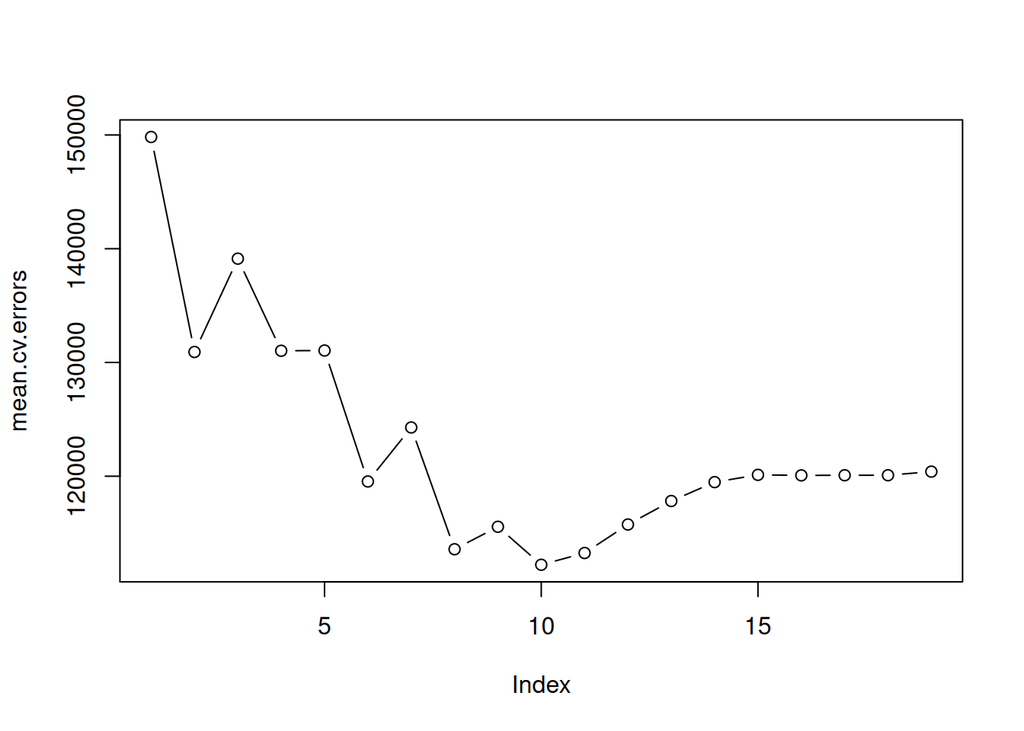

```r
par(mfrow=c(1,1))
plot(mean.cv.errors ,type='b')
```

```r
which.min(mean.cv.errors)
```

```
## 10
## 10
```

```r
reg.best=regsubsets (Salary~.,data=Hitters , nvmax=19)
coef(reg.best ,which.min(mean.cv.errors))
```

```
##  (Intercept)        AtBat         Hits        Walks       CAtBat        CRuns
##  162.5354420   -2.1686501    6.9180175    5.7732246   -0.1300798    1.4082490
##         CRBI       CWalks    DivisionW      PutOuts      Assists
##    0.7743122   -0.8308264 -112.3800575    0.2973726    0.2831680
```